# Main and supplementary figures and analysis for *Varroa Destructor* Inheritance Study

Nurit Eliash and Sasha Mikheyev

03 August, 2025

This document contains analyses and figures for our study on the mode of genetic inheritance in *Varroa destructor*.  
The full paper by Eliash et al. 2025, “Varroa mites escape the evolutionary trap of haplodiploidy”, can be found in [here](https://www.biorxiv.org/content/10.1101/2024.05.10.593493v2).

The document is composed of two main sections:

- Supplementary figures
- Main figures

Note, that apart from Figure S1 (Karyotyping of varroa males and females), all the rest of the analysis and figures are focused on the Genomic Pedigree study.

# Supplementry figures

## Figure S1: Karyotyping of varroa males and females

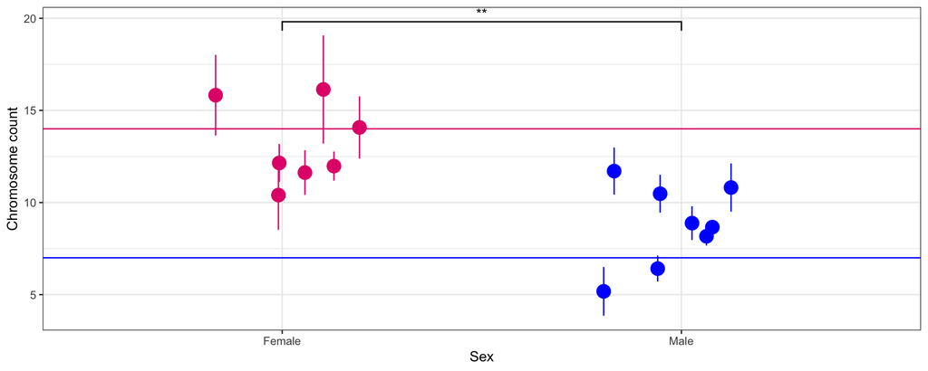

```r
dat <- read_csv("/Users/nuriteliash/Documents/GitHub/varroa-karyotyping/data/karyo_varroa_sasha.csv", col_types = "cccnnn")

dat_means <- dat %>% group_by(ID) %>%
    reframe(
        chroms = sum(cell_count * chromo_number) / sum(cell_count),
        count = sum(cell_count),
        sd = sqrt(sum(cell_count * (chromo_number - chroms)^2) / sum(cell_count)),
        sem = sd / sqrt(count),
        ci_lower = chroms - qt(0.975, df = count - 1) * sem,
        ci_upper = chroms + qt(0.975, df = count - 1) * sem,
        sex = Sex[1])

dat_means %>%
ggplot(aes(x = sex, y = chroms, color = sex, size = count)) +
  geom_pointrange(aes(ymin = ci_lower, ymax = ci_upper), size = 1, width = 0.05, position=position_jitter(width=0.2)) +
  scale_color_manual(values = c("Male" = "blue", "Female" = "#E31C79")) +  # Custom colors
  scale_size_continuous(range = c(3, 10)) +  # Custom size range
  geom_hline(yintercept = 7, color = "blue") +
  geom_hline(yintercept = 14, color = "#E31C79") +
  theme_bw() +
  ylab("Chromosome count") +
  geom_signif(comparisons = list(c("Male", "Female")), map_signif_level = TRUE, test = "wilcox.test", color = "black") +
  scale_y_continuous(breaks = scales::breaks_pretty()) +
  theme(legend.position = "bottom") +
  guides(color = "none") +
  labs(size = "Number of cells examined per individual") +
  xlab("Sex")
```

```r
#ggsave("karyptype.pdf", heigh=5, width=5)
```

Do males have significantly less chromosomes than the diploid number of 14?

```r
filter(dat_means, sex == "Male") %>% pull(chroms) %>% t.test(., mu = 14)
```

```
##
##  One Sample t-test
##
## data:  .
## t = -6.5908, df = 7, p-value = 0.0003069
## alternative hypothesis: true mean is not equal to 14
## 95 percent confidence interval:
##   6.926898 10.662108
## sample estimates:
## mean of x
##  8.794503
```

## Genomic Pedigree study

This analysis is part of a comprehensive study investigating the genetic inheritance patterns in *Varroa destructor* mites. We analyzed genomic data from 223 mite samples across 30 families, collected from three *Apis mellifera* colonies. Each family consists of three generations: F0 foundress adult female mite, F1 male and female adult offspring mites, and their F2 offspring, composed of immature mites (nymphs and eggs) and at least one adult male.

The analysis should be read in conjunction with the detailed methodology presented in [Site Quality Analysis](https://github.com/nurit-eliash/varroa-pedigree-study/blob/main/R_scripts/After_revision/site_quality_exploration.Rmd).

### Data Availability

- Raw sequencing data: [BioProject PRJNA794941](https://www.ncbi.nlm.nih.gov/bioproject/PRJNA794941/)
- Analysis code: [GitHub Repository](https://github.com/nurit-eliash/varroa-pedigree-study/)
- Filtered datasets: Available upon request

### Data Sources

- Raw fastq reads: [BioProject PRJNA794941](https://www.ncbi.nlm.nih.gov/bioproject/PRJNA794941/)
- Code repository: [GitHub](https://github.com/nurit-eliash/varroa-pedigree-study/tree/main#varroa-pedigree-study)

### Required Files

Before running this analysis, ensure you have:  
1. The VCF file processed with the specified parameters  
2. The filtered sites CSV file generated from site quality exploration  
3. All required R packages installed

## VCF File Processing

The initial variant calling file was filtered using VCFtools with stringent quality control parameters to ensure high-confidence variant calls. The filtering criteria were:

```bash
vcftools --vcf snponly_freebayes.vcf \
  --chr NW_019211454.1 \
  --chr NW_019211455.1 \
  --chr NW_019211456.1 \
  --chr NW_019211457.1 \
  --chr NW_019211458.1 \
  --chr NW_019211459.1 \
  --chr NW_019211460.1 \
  --max-alleles 2 \
  --minQ 15000 \
  --minDP 16 \
  --maxDP 40 \
  --max-missing 0.5 \
  --maf 0.2 \
  --recode \
  --recode-INFO-all \
  --out Q15000BIALLDP16HDP40mis.5maf.2Chr7
```

### VCF file filtering rationale

- **Chromosomes**: Selected the 7 largest chromosomes (NW_019211454.1-460.1)
- **Alleles**: Limited to biallelic sites to focus on clear binary inheritance patterns
- **Quality**: Minimum Phred score of 15000 ensures high base quality
- **Depth**: Range of 16-40 balances between coverage requirements and potential artifacts
- **Missing Data**: Maximum 50% missing data per site maintains statistical power
- **Minor Allele Frequency**: Minimum 0.2 reduces impact of sequencing errors

## Quality Control Metrics

We implemented three key metrics to assess genotype quality:

1. **Variant Quality Distribution** (see Figure S6)
2. **Variant Allele Frequency (VAF)**
   - Calculated as: VAF = AO/DP
   - AO: Alternate allele observations
   - DP: Total read depth
   - Provides measure of allelic balance
3. **Quality Allele Frequency (QAF)**
   - Calculated as: QAF = QA/(QA+QO)
   - QA: Quality scores for alternate allele
   - QO: Quality scores for reference allele
   - Weights allele calls by base quality

### Figure S6: Variant Quality Distribution

```
## Summary of variant quality scores:
```

```
##      Min.   1st Qu.    Median      Mean   3rd Qu.      Max.
##     40.48  33240.80  48198.10  52338.46  69672.30 191031.00
```

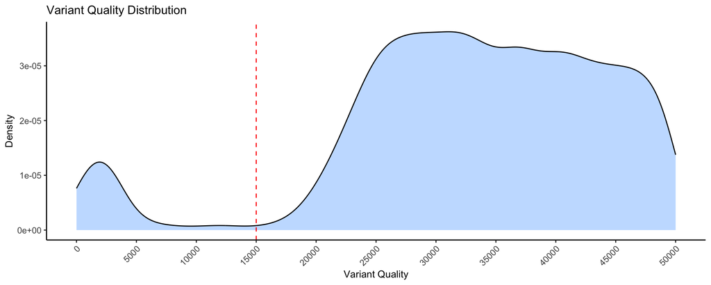

[output not shown]

### Genotype Classification Thresholds, VAF and QAF

Based on empirical distribution analysis (see the following figures S7-9), we established the following thresholds:

| Genotype | VAF Range | QAF Range | Interpretation |
| --- | --- | --- | --- |
| AA (Ref) | < 0.01 | < 0.01 | Strong reference support |
| AB (Het) | 0.2 - 0.8 | 0.2 - 0.8 | Balanced allele representation |
| BB (Alt) | > 0.9 | > 0.9 | Strong alternate support |

These thresholds were validated using known inheritance patterns in our pedigree structure.

The site quality filtering criteria were developed based on Variant Allele Frequency (VAF) and Genotype Quality Allele Frequency (QAF) analysis. For detailed methodology and validation of these thresholds, see Site Quality Analysis.

We applied two additional filtering parameters to account for biases in alternate allele representation and to ensure high-confidence genotype calls based on allele frequency and quality.  
*Variant allele frequency (VAF)* was calculated as VAF = AO/DP, where AO (Alternate Observations) represents the number of reads supporting the alternate allele, and DP (Depth) is the total read depth at the site.  
Similarly, *Quality Allele Frequency (QAF)* was computed as QAF = QA/QA+QO, where QA (Quality of Alternate Allele) is the sum of Phred-scaled base quality scores for reads supporting the alternate allele, and QO (Quality of Reference Allele) is the sum of Phred-scaled base quality scores for reads supporting the reference allele.

## Figure S7-9 : Picking the thresholds for site quality: Distribution of VAF and QAF in F2 Offspring of homozygous parents

### Figure S7, Quality Allele Frequency (QAF) and Variant Allele Frequency (VAF) in F2 females of AA parents.

```r
# Read the f2_homo_parents data (sanity check data) from CSV: F2 females at the filtered positions, on chrom 1, where F1 male and female are homozygous (AA)
# the file was created using the ~/Documents/GitHub/varroa-pedigree-study/R_scripts/After_revision/site_quality_exploration.Rmd
f2_AA_parents <- read.csv("/Users/nuriteliash/Documents/GitHub/varroa-pedigree-study/data/f2_AA_parents.csv")
```

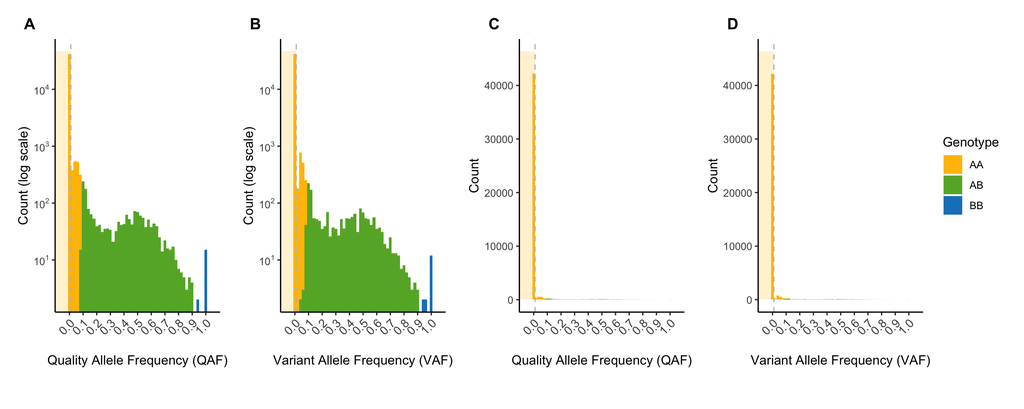

[output not shown]

### Figure S8, Quality Allele Frequency (QAF) and Variant Allele Frequency (VAF) in F2 females of BB parents.

```r
# Read the f2_homo_parents data (sanity check data) from CSV: F2 females at the filtered positions, on chrom 1, where F1 male and female are homozygous (AA)
# the file was created using the ~/Documents/GitHub/varroa-pedigree-study/R_scripts/After_revision/site_quality_exploration.Rmd
f2_BB_parents <- read.csv("/Users/nuriteliash/Documents/GitHub/varroa-pedigree-study/data/f2_BB_parents.csv")
```

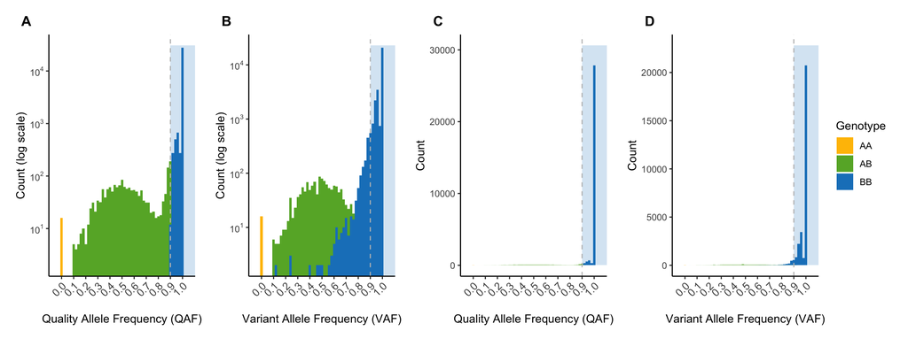

[output not shown]